# Conceitos de filogenética

Author

Affiliation

Gabriel Rodrigues, MSc

Universidade Estadual de Santa Cruz

Published

October 24, 2025

Abstract

Resumo das aulas da disciplina “Filogenia Molecular” ministradas pelo Professor Marco Antônio Costa, da Universidade Estadual de Santa Cruz (UESC).

Keywords

Árvore Filogenética, Evolução, Métdos Moleculares

# Conceitos chave

## Homoplasia

Caracteres semelhantes adquiridos independentemente. Pode ser classificado como:

- **Reversão**: Exibe uma derivação de um ancestral comum menos recente, em um ramo mais anterior da árvore. Dados com muita reversão podem ser visto com estranheza;
- **Paralelismo**: Uma evolução em paralelo que ocorre em ramos diferentes e em momentos diferentes, mas exibem os mesmos caracteres;
- **Convergência**: Quando há uma pressão de seleção que levam a diferentes linhagens (que podem ser transitórias), que levam à convergência da linhagem.

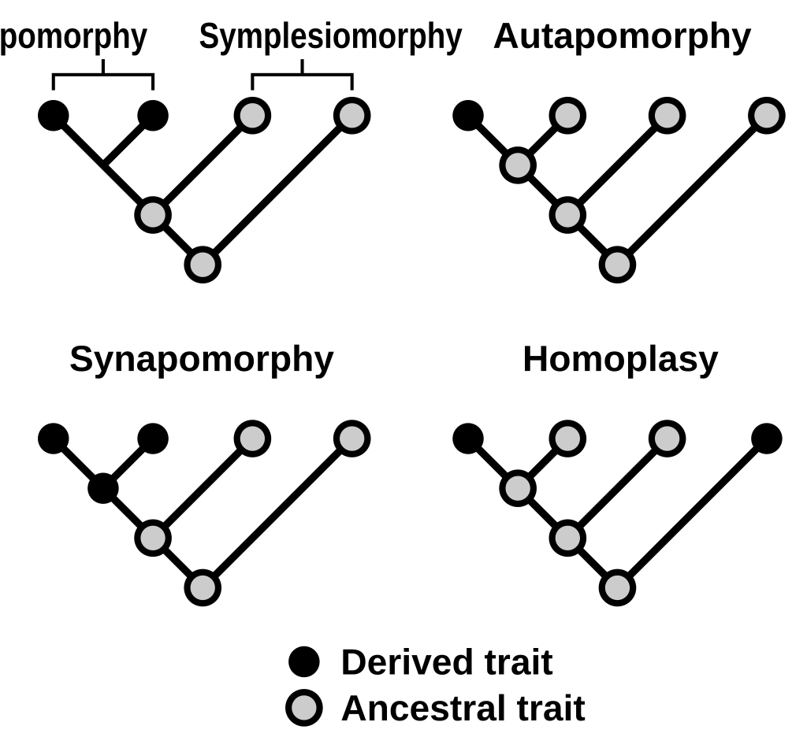

Homosplasia

## Plesiomorfia

Característica considerada primitiva dentro de uma linhagem evoutiva por ser semelhante ao grupo ancestral.

## Apomorfia

Característica considerada derivada dentro da linhagem evolutia, por ser diferente do grupo ancestral. Características mais recentes dentro da linhagem. **Sinamoporfia** é quando dois ou mais linhagens compartilham um novo caráter.

**Autapomorfia** é quando uma folha ou ramo novo tem uma caracteística muito única dentro da linhagem. Espécies autapomorfas podem ser determinadas pelas distâncias maiores nos ramos.

# Conceitos Evolutivos

## Especiação

Origem de novas linhagens a partir da linhagem ancestral, podendo ou não diferir nas características morfológicas, porém com isolamento reprodutivo. Os eventos de especiação são as bifurcações nos ramos da árvore.

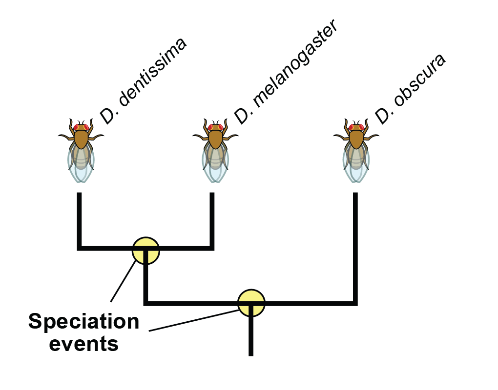

Especiação

## Filogenia

Hipótese sobre as relações evolutivas entre um grupo de táxons ou OTUs.

Citação vinda de AVISE (1994,2004) - “Molecular Markers, Natural History, and Evolution”.

> Os dados moeleculars são genéticos. Com o conhecimento da quantidade e conhecimando da variação estudada, conclusões confiáveis podem ser geitas sobre a filogenia a partir de dados moleculares. Raramente os genes e alelos que controlam determinadas características morfológicas, fisiológicas ou comportamentais utilizadas na taxonomia convencional podem ser identificados.

Avise teve o trabalho de propagar a ideia de filogenia molecular para os taxonomistas e sistematas.

### Classificação

Categorização de entidades em grupos por uma semelhança entre as mesmas e diferenças entre os grupos.

# Métodos moleculares (extra)

## Eletromorfos e eletroforese

Em biologia molecular, eletromorfos são variantes de enzimas ou outras proteínas que possuem a mesma função, mas que podem ser diferenciadas pela técnica de eletroforese em gel. A diferença na migração no gel é causada por variações na carga elétrica, massa ou estrutura da molécula, que geralmente resultam de mutações genéticas.

Segundo o Prof. Marco Antônio, os géis utilizados nos eletromorfos eram a base de amido industrial - vindo de fornecedores industriais.

## Polimorfismo de Enzimas de Restrição - PCR e RFLP

**RFLP** - *Restriction fragment length polymorphism*. Endonucleases que cortam aleatoriamente as seqûencias de um gene/genoma, as diferenças nos fragmentos e nas bandas irão determinar as semelhanças e diferenças entre as amostras.

## Cariótipo

Observação das diferenças cromossômicas, são diferenças estruturais/quantitativas que irão determinar as distâncias entre as espécies na filogenia final. O mapeamento dos cromossomos é o input da análise.

Os eventos de divisões cromossômicas podem também interferir nas distências e proximidades entre as espécies.

# Relações de Homologia, Paralogia e Ortologia

Em uma relação evolutiva de genes, eventos de duplicação gênica podem ocorrer e mudar a dinâmica da análise dos genes na história evolutiva.

```
flowchart LR
  A(Gene A) -- Duplicação Gênica --> AB{Gene A e B}
  AB --> A1B1(Gene A1 e B1)
  AB --> A2B2(Gene A2 e B2)
  A1B1 --> A1(Gene A1)
  A1B1 --> B1(Gene B1)
  A2B2 --> A2(Gene A2)
  A2B2 --> B2(Gene B2)
```

O evento de duplicação do `Gene A` gerou os genes *A* e *B*, e as espécies subsequentes carregam os genes com as seguintes relações.

```
flowchart LR
  X1(Gene A1) -- Genes Ortólogos --- X2(Gene A2)
  X1(Gene A1) -- Genes Parálogos --- Y2(Gene B2)

  T1(Gene A1) -- Genes Homólogos --- T2(Gene A2)
```

Os genes `A1` e `A2` são Ortólogos, e ao mesmo tempo também são Homólogos.

# Seleção de genes para uma filogenia

A escolha dos genes para a execução de uma filogenia é uma etapa fundamental para entender as relações basais na árvore filogenética final. Existem os chamados métodos de “concatenação”, onde diferentes genes são concatenados para formar uma única sequência utilizada para a filogenia final.

Os genes escolhidos para concatenação devem ser cuidadosamente escolhidos, pois devem possuir uma taxa de variação similar e serem bem representativos para o táxon analisado. Sequências muito conservadas podem silenciar a real variação dos genes mais distintos.